# Group 26: Arcene Cancer

Author

Todd Davison, Greta Medlam, Douglas Blackwood, Mariam El Mawed

# 1 Introduction

This file contains code and analysis for the classification of cancerous tissue, based on dimension reduction and various classification methods.

We use the following training and test data sets, that each contain 100 samples of either cancerous or non-cancerous tissue samples.

```r
training <- read.csv("group_26.csv")
test <- read.csv("arcene_test.csv")
```

We look at the dimensions of the test and training sets.

```r
X_train <- as.matrix(training[,-1])
y_train <- as.matrix(training[,1])

X_test <- as.matrix(test[,-1])
y_test <- as.matrix(test[,1])

data.frame(Training_set = dim(X_train),
           Test_set = dim(X_test),
           row.names = c("Observations", "Features")) %>%
  gt(rownames_to_stub = T)
```

|  | Training_set | Test_set |
| --- | --- | --- |
| Observations | 100 | 100 |
| Features | 2506 | 9920 |

There are 2506 features and 100 observations in the training set.

We now look for missing data.

```r
X_train_df <- as.data.frame(X_train)

total_missing <- sum(is.na(X_train_df))
```

No missing data.

We look at the split of cancerous to non-cancerous observations.

```r
cancerous <- training[training$Class == 1,]
dim(cancerous)
```

```
[1]   44 2507
```

So we have 44 cancerous tissue samples and 56 non-cancerous samples.

We also look at the test set split.

```r
cancerous <- test[test$Class == 1,]
dim(cancerous)
```

```
[1]   44 9921
```

We look at the correlation between variables, as PCA works best when variables are highly correlated.

```r
corr_mat <- cor(X_train)
cors <- corr_mat[upper.tri(corr_mat)]

mean_cor <- mean(cors)
mean_cor
```

```
[1] 0.03103134
```

This is very low. However there are dummy variables in the dataset, so this mean may be skewed by dummy variables with very little/no correlation to non-dummy variables.

```r
high_count <- sum(abs(cors) >= 0.67)
mid_count <- sum(abs(cors) >= 0.33 & abs(cors) < 0.67)
little_count <- sum(abs(cors) >= 0.01 & abs(cors) < 0.33)
zero_count   <- sum(abs(cors) < 0.01)

c(
  Highly_correlated = high_count,
  Mild_correlation = mid_count,
  Little_correlation = little_count,
  Near_zero_correlation = zero_count
)
```

```
    Highly_correlated      Mild_correlation    Little_correlation
               128126                474021               2382999
Near_zero_correlation
               153619
```

While a majority of variables have little to no correlation there is a significant amount with high or mild correlation, so PCA should still work reasonably well.

We will now check if the variables are on the same scale.

```r
# standard deviations of variables
sds <- apply(X_train, 2, sd, na.rm = TRUE)
summary(sds)
```

```
   Min. 1st Qu.  Median    Mean 3rd Qu.    Max.
   0.10   22.16   40.74   59.33   82.70  316.23
```

There is a large difference between the min and max, so we look at a boxplot.

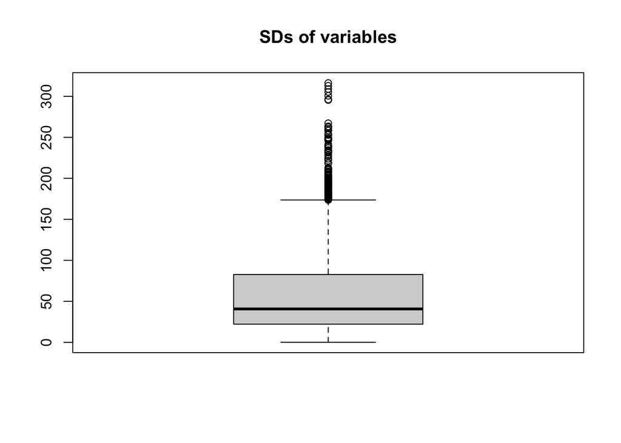

```r
boxplot(sds, main = "SDs of variables")
```

From this we can see the variables have different scales, so we will use the correlation matrix instead of covariance matrix for PCA and we will scale the data when using MDS.

## 1.1 Dimension Reduction

We perform PCA using the correlation matrix.

```r
pca_fit <- prcomp(X_train, scale = T)
pca_summary <- summary(pca_fit)
pca_summary$importance[, 1:50]
```

```
                            PC1      PC2      PC3      PC4     PC5      PC6
Standard deviation     23.90770 16.44442 11.98557 10.30092 9.42222 8.838759
Proportion of Variance  0.22808  0.10791  0.05732  0.04234 0.03543 0.031170
Cumulative Proportion   0.22808  0.33599  0.39332  0.43566 0.47108 0.502260
                            PC7      PC8      PC9     PC10     PC11     PC12
Standard deviation     7.508606 7.119311 6.717906 6.310745 5.993659 5.462484
Proportion of Variance 0.022500 0.020230 0.018010 0.015890 0.014340 0.011910
Cumulative Proportion  0.524760 0.544980 0.562990 0.578880 0.593220 0.605130
                           PC13     PC14     PC15     PC16    PC17     PC18
Standard deviation     5.281483 5.095247 4.999438 4.887321 4.84586 4.630272
Proportion of Variance 0.011130 0.010360 0.009970 0.009530 0.00937 0.008560
Cumulative Proportion  0.616260 0.626620 0.636590 0.646120 0.65549 0.664050
                           PC19     PC20     PC21    PC22     PC23     PC24
Standard deviation     4.553417 4.505403 4.451095 4.36740 4.272298 4.236042
Proportion of Variance 0.008270 0.008100 0.007910 0.00761 0.007280 0.007160
Cumulative Proportion  0.672320 0.680420 0.688330 0.69594 0.703220 0.710380
                           PC25    PC26     PC27     PC28     PC29    PC30
Standard deviation     4.197469 4.10148 4.048872 4.024978 3.919072 3.89653
Proportion of Variance 0.007030 0.00671 0.006540 0.006460 0.006130 0.00606
Cumulative Proportion  0.717410 0.72413 0.730670 0.737130 0.743260 0.74932
                           PC31     PC32     PC33     PC34     PC35     PC36
Standard deviation     3.819673 3.810863 3.762431 3.755796 3.705813 3.688378
Proportion of Variance 0.005820 0.005800 0.005650 0.005630 0.005480 0.005430
Cumulative Proportion  0.755140 0.760940 0.766590 0.772210 0.777690 0.783120
                           PC37     PC38     PC39     PC40     PC41     PC42
Standard deviation     3.622986 3.602342 3.593537 3.551196 3.541295 3.482166
Proportion of Variance 0.005240 0.005180 0.005150 0.005030 0.005000 0.004840
Cumulative Proportion  0.788360 0.793540 0.798690 0.803720 0.808730 0.813570
                           PC43     PC44    PC45     PC46     PC47     PC48
Standard deviation     3.468185 3.442207 3.40282 3.393573 3.372526 3.338926
Proportion of Variance 0.004800 0.004730 0.00462 0.004600 0.004540 0.004450
Cumulative Proportion  0.818370 0.823100 0.82772 0.832310 0.836850 0.841300
                           PC49     PC50
Standard deviation     3.320465 3.310005
Proportion of Variance 0.004400 0.004370
Cumulative Proportion  0.845700 0.850070
```

From this we can see the first 40 principal components (PCs) explain 80% of the variability, and 50 explains 85% of the variability.

We look at a scree plot.

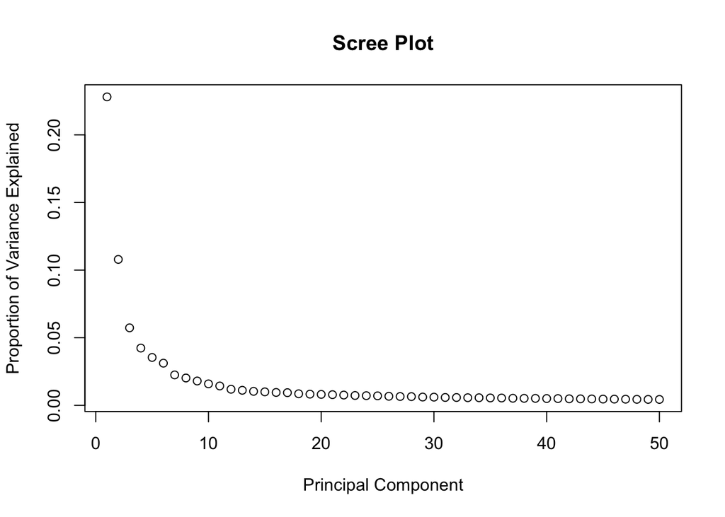

```r
# Proportion of variance explained
pve <- (pca_fit$sdev^2) / sum(pca_fit$sdev^2)

# Scree plot
plot(
  1:50, pve[1:50],
  xlab = "Principal Component",
  ylab = "Proportion of Variance Explained",
  main = "Scree Plot"
)
```

From the scree plot we can see the “elbow” appears between 8 and 15 PCs approximately.

Since 40 PCs explain 80% of the variability, we will proceed with this as our default number of PCs.

```r
#Select/Choose the first 40 pcs which explains 90% of the variation

k <- 40   # number of PCs you decided to keep

X_train_pca <- pca_fit$x[, 1:k]

# Test PCA scores
X_test_pca <- predict(pca_fit, newdata = X_test)[, 1:k]
```

We can also use MDS for dimension reduction, however it doesn’t have a predict function to map data from the test set to the same space that the model was trained on. Hence, we will not use it for classification models.

We will now perform Classical MDS.

```r
# Euclidean distances for training points
D_train <- dist(scale(X_train), method = "euclidean")

# classical MDS to k dimensions
cmds_fit <- cmdscale(D_train, k = 90, eig = T)
cmds_fit$GOF
```

```
[1] 0.9812283 0.9812283
```

This gives a very good goodness of fit value for k = 90.

We will now look at various classification methods, using PCA.

## 1.2 K-Nearest Neighbours

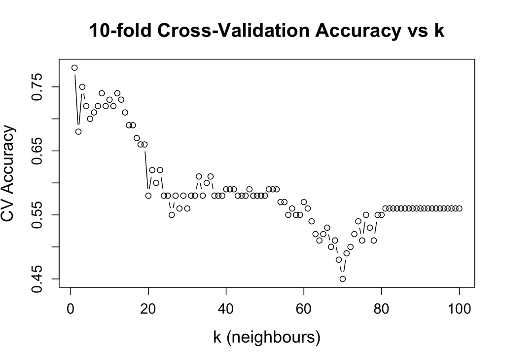

```
    K CV_Accuracy
1   1        0.78
3   3        0.75
8   8        0.74
12 12        0.74
10 10        0.73
13 13        0.73
4   4        0.72
7   7        0.72
9   9        0.72
11 11        0.72
```

```
[1] 1
```

```
  [1] -1 1  -1 1  1  1  -1 1  -1 1  1  -1 -1 1  -1 -1 -1 1  1  1  1  -1 1  -1 1
 [26] 1  -1 1  -1 -1 -1 -1 1  1  1  -1 -1 -1 1  -1 1  -1 -1 1  1  -1 -1 1  1  -1
 [51] -1 -1 1  -1 -1 -1 -1 1  1  1  1  1  1  -1 -1 -1 -1 1  -1 -1 1  -1 1  -1 -1
 [76] 1  1  -1 1  -1 1  -1 -1 1  1  -1 1  1  1  -1 1  -1 -1 1  1  -1 -1 1  1  1
Levels: -1 1
```

```
         Actual
Predicted -1  1
       -1 45  5
       1  11 39
```

| Actual | Predicted -1 | Predicted 1 |
| --- | --- | --- |
| -1 | 45 | 5 |
| 1 | 11 | 39 |

```
[1] 0.8863636
```

```
[1] 0.8035714
```

| Metric | Value |
| --- | --- |
| Accuracy | 0.8400000 |
| Sensitivity | 0.8863636 |
| Specificity | 0.8035714 |

We computed the confusion matrix, sensitivity, specificity, and accuracy for the final KNN classifier using K = 1. Sensitivity measures the ability to correctly identify cancerous samples (class = 1), while specificity measures the ability to correctly identify non‑cancerous samples (class = −1). The accuracy represents the overall proportion of correctly classified observations.

## 1.3 Discriminant

###Linear Discriminant Analysis

After applying PCA for dimensionality reduction, we first convert the PCA components into data frame and fit LDA model with equal class priors probabilityies of 1/2. The model then learns the linear combination of PCs that best separates cancerous and non‑cancerous samples.

```
  Group.1      PC1      PC2       PC3       PC4       PC5       PC6      PC7
1      -1 603.2243 256.4693 227.44853 169.83412 118.98530 109.32842 58.75610
2       1 441.9287 291.7377  39.74064  22.77803  47.99166  37.88259 54.03922
       PC8      PC9     PC10     PC11     PC12     PC13     PC14     PC15
1 39.77509 38.06003 34.19424 38.35784 13.55817 24.56736 16.96137 31.23315
2 64.70833 52.66952 42.48572 28.60893 48.60538 19.65895 37.61601 17.36262
      PC16     PC17     PC18     PC19     PC20     PC21     PC22     PC23
1 21.07166 24.57128 16.76327 22.25802 24.73611 20.15401 21.51589 16.34630
2 28.01001 22.14906 27.91008 19.24848 14.27031 19.33210 15.61154 20.57875
      PC24     PC25     PC26     PC27     PC28     PC29     PC30      PC31
1 15.71625 13.00958 18.37767 11.02279 19.30578 18.35095 12.41012 18.601411
2 21.19221 23.89715 15.15250 23.24026 12.51692 11.57534 18.62306  9.784954
      PC32     PC33     PC34     PC35      PC36     PC37      PC38     PC39
1 10.20479 17.29399 13.99737 14.09516 17.122430 14.62624 16.430067 15.24051
2 19.97850 10.46315 14.43969 13.16370  9.378114 11.22682  8.561833 10.09057
       PC40
1 18.828344
2  4.951402
```

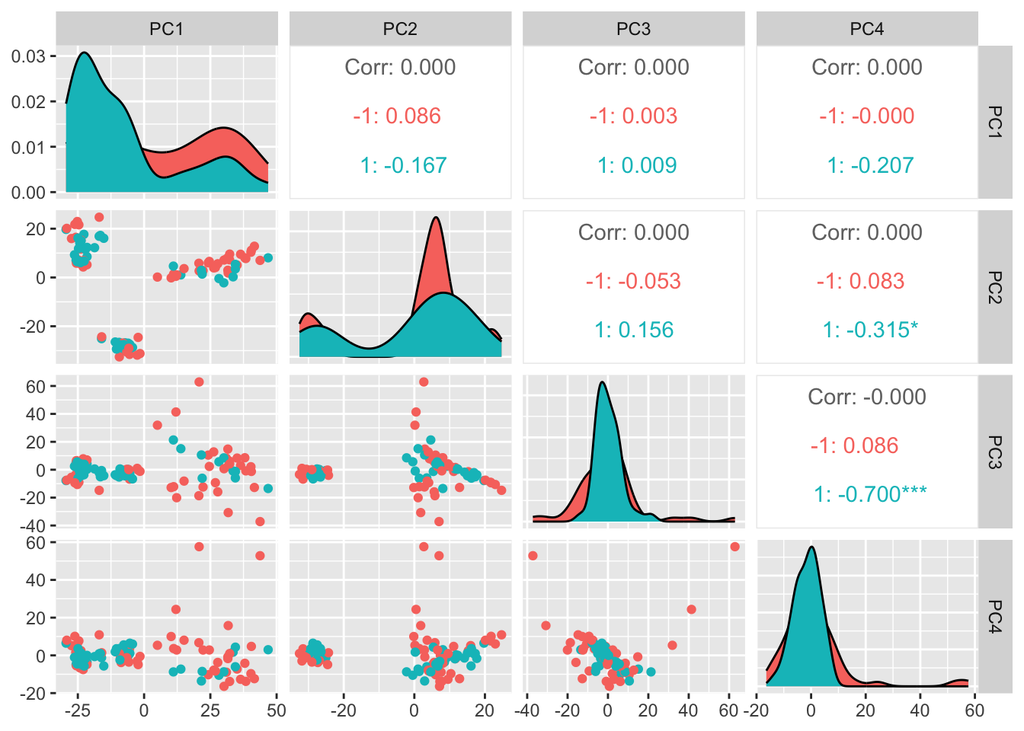

```
         Actual
Predicted -1  1
       -1 46 11
       1  10 33
```

| Actual | Predicted -1 | Predicted 1 |
| --- | --- | --- |
| -1 | 46 | 11 |
| 1 | 10 | 33 |

```
[1] 0.75
```

```
[1] 0.8214286
```

| Metric | Value |
| --- | --- |
| Accuracy | 0.7900000 |
| Sensitivity | 0.7500000 |
| Specificity | 0.8214286 |

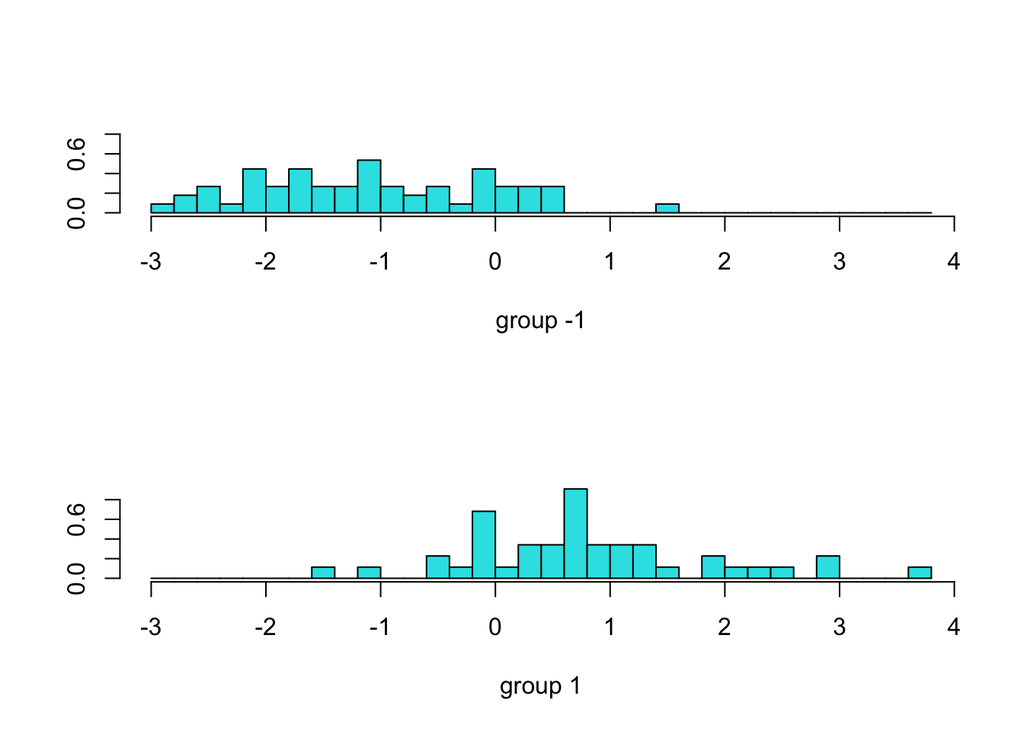

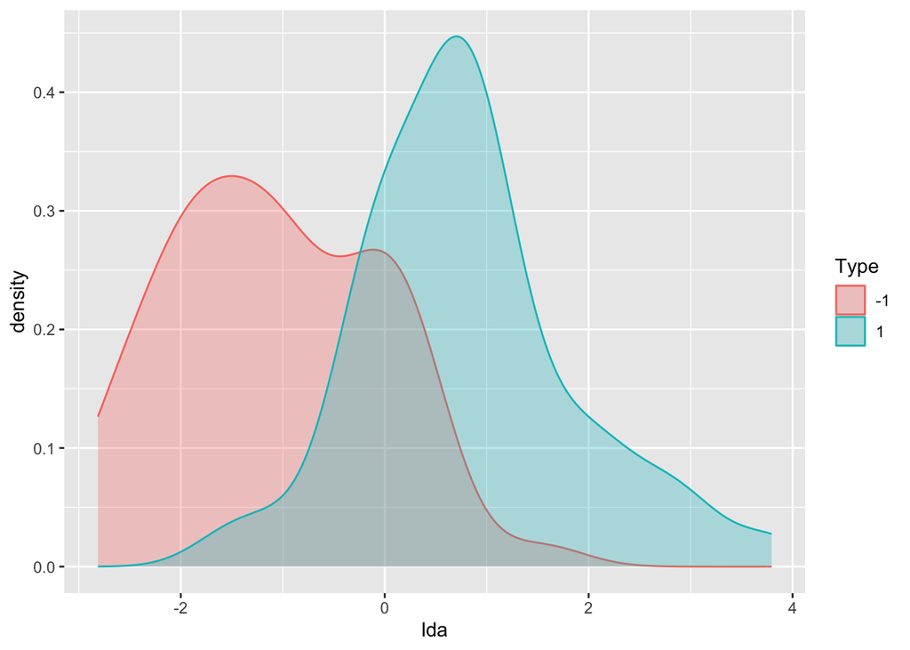

We then visualise how well the samples separate along the first linear discriminant using density plots and LDA histograms. In both plots, the x‑axis represents LD1 scores, which are the projections of each observation onto the linear discriminant direction. These show how well the classes separate along the discriminant axis and provide insight into the model’s classification performance. Class −1 values are mostly negative, while class 1 values are mostly positive with a small overlap around LD1=0. This indicates that LDA’s linear boundary effectively separates the cancerous and non‑cancerous groups.

Although several PCs showed similar within class variances, others displayed noticeable differences, indicating that the equal covariance assumption is only approximately satisfied. Therefore, LDA is still appropriate, but we also fit QDA.

###Quadratic Discriminant Analysis

After fitting QDA on the PCA transformed training data, we predicted the test set and calculated accuracy, sensitivity, specificity, and the confusion matrix. QDA is therefore evaluated solely through its classification results (accuracy, sensitivity, specificity).

```
[1] 0.61
```

```
         Actual
Predicted -1  1
       -1 55 38
       1   1  6
```

| Actual | Predicted -1 | Predicted 1 |
| --- | --- | --- |
| -1 | 55 | 38 |
| 1 | 1 | 6 |

```
[1] 0.1363636
```

```
[1] 0.9821429
```

| Metric | Value |
| --- | --- |
| Accuracy | 0.6100000 |
| Sensitivity | 0.1363636 |
| Specificity | 0.9821429 |

## 1.4 Support Vector Machines

Support Vector Machines (SVM) is a supervised learning technique used to classify data. Here we will be using SVM to classify the variable ‘Class’. Class is conveniently in the format already required by SVM of being binary with values -1, 1 for non-cancerous and cancerous respectively.

In the following code, different kernels will be tuned based on error and compared using 10-fold cross validation. Each SVM model will have AUC calculated based on ROC plot, as a measure of ‘goodness of fit’, as such models will be compared. Through comparison of confusion matrix calculated for each model, the model selection/optimisation process can take place to determine the best SVM classification model to detect cancerous cells in the test set.

Initially, a baseline AUC value must be caluated using default cost, C-classification and linear kernel.

```r
# Preprocess data for SVM and set seed
# Initially we use 40 pc's

n_pcs <- 40
train_data <- as.data.frame(pca_fit$x[, 1:n_pcs])

train_data$Class <- y_train

test_data  <- as.data.frame(predict(pca_fit, X_test)[, 1:n_pcs])

# SVM must have repsonse as factors
test_data$Class <- as.factor(y_test)
```

Fit Baseline SVM:

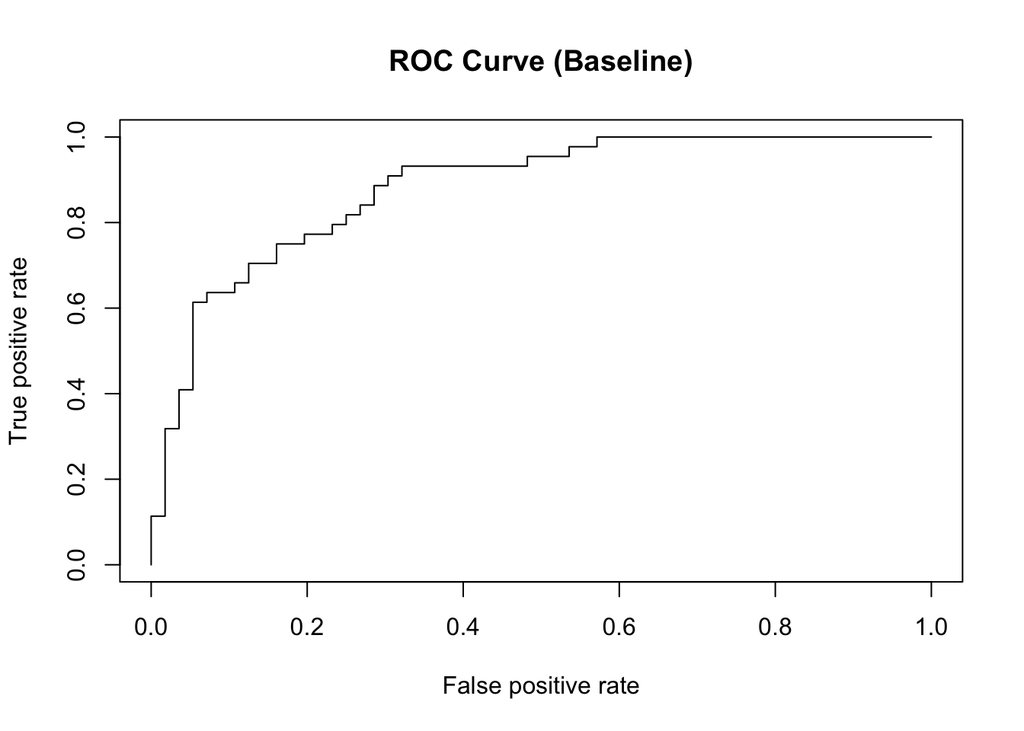

```r
set.seed(1)
# test baseline model, plotting ROC and calculating AUC
SVM_model1 <- svm(Class ~ ., data = train_data, type = "C-classification", kernel = "linear", cost = 1, decision.values = TRUE)

# Calcualte confidence scores for ROC curve
scores_model1 <- attributes(predict(SVM_model1, test_data, decision.values = TRUE))$decision.values


# Use ROCR:: 'ROCR::' as had error woth libraries
pred_model1 <- ROCR::prediction(scores_model1, test_data$Class)
perf_model1 <- ROCR::performance(pred_model1, "tpr", "fpr")

# Plot Roc curve for Baseline Model
par(mfrow = c(1, 1))
plot(perf_model1, main = "ROC Curve (Baseline)")
```

```r
# Calcualte AUC for baseline model
auc_model1 <- ROCR::performance(pred_model1, "auc")@y.values[[1]]

auc_model1
```

```
[1] 0.880276
```

```r
# 0.88


# Classification error and confusion matrix
pred_class_model1 <- predict(SVM_model1, test_data)
error_model1 <- mean(pred_class_model1 != test_data$Class)
error_model1
```

```
[1] 0.21
```

```r
table(ActualClass = test_data$Class, Prediction = pred_class_model1)
```

```
           Prediction
ActualClass -1  1
         -1 50  6
         1  15 29
```

```r
# We get 29 TP, 50 TN, 6 FP, 15 FN
```

For model 1, our baseline model, we see an AUC of approximately 0.88. This is a well fitting model to start off with. We see that this model has 15 false negative values.

We will now try to optimise the model through comparison of cost, linear vs non-linear boundary and principal components.

Linear Cost Analysis: Cost value tells the function how many miss classifications are allowed i.e. false positive or false negative. Higher cost value can result in overfitting. We want to optimise cost so we can reduce the false negative results.

```r
# To use tune we need the class variables as factors in both data sets

train_data$Class <- as.factor(train_data$Class)
test_data$Class  <- as.factor(test_data$Class)


# use tune function for cross-validation testing of different cost values
set.seed(1)
linear.tune<-tune(svm, Class~., data=train_data,
                  type="C-classification", kernel="linear",
                  ranges=list(cost=c(0.1,1,10,100)))
summary(linear.tune)
```

```
Parameter tuning of 'svm':

- sampling method: 10-fold cross validation

- best parameters:
 cost
  0.1

- best performance: 0.26

- Detailed performance results:
   cost error dispersion
1   0.1  0.26  0.1074968
2   1.0  0.40  0.1490712
3  10.0  0.37  0.1337494
4 100.0  0.37  0.1337494
```

```r
summary(linear.tune)$best.parameters
```

```
  cost
1  0.1
```

```r
# We see from this that the best cost value will be 0.1, as error is lowest at 0.26, also dispersion is lowest, we notice however, error has a positive trend with cost so we may try smaller cost to see if trend continues.

set.seed(1)
linear.tune2 <-tune(svm, Class~., data=train_data,
                  type="C-classification", kernel="linear",
                  ranges=list(cost=c(0.01, 0.03, 0.05, 0.07, 0.1)))
summary(linear.tune2)
```

```
Parameter tuning of 'svm':

- sampling method: 10-fold cross validation

- best parameters:
 cost
 0.03

- best performance: 0.24

- Detailed performance results:
  cost error dispersion
1 0.01  0.35  0.1269296
2 0.03  0.24  0.1349897
3 0.05  0.24  0.1349897
4 0.07  0.26  0.1074968
5 0.10  0.26  0.1074968
```

```r
summary(linear.tune2)$best.parameters
```

```
  cost
2 0.03
```

```r
# We see that for this somewhere between (not including) cost = 0.01 to cost = 0.07 gives us the lowest error, We will try again within this range.

set.seed(1)
linear.tune3 <-tune(svm, Class~., data=train_data,
                  type="C-classification", kernel="linear",
                  ranges=list(cost=c(0.02, 0.03, 0.04, 0.05, 0.06)))
summary(linear.tune3)
```

```
Parameter tuning of 'svm':

- sampling method: 10-fold cross validation

- best parameters:
 cost
 0.03

- best performance: 0.24

- Detailed performance results:
  cost error dispersion
1 0.02  0.31  0.1370320
2 0.03  0.24  0.1349897
3 0.04  0.25  0.1354006
4 0.05  0.24  0.1349897
5 0.06  0.24  0.1264911
```

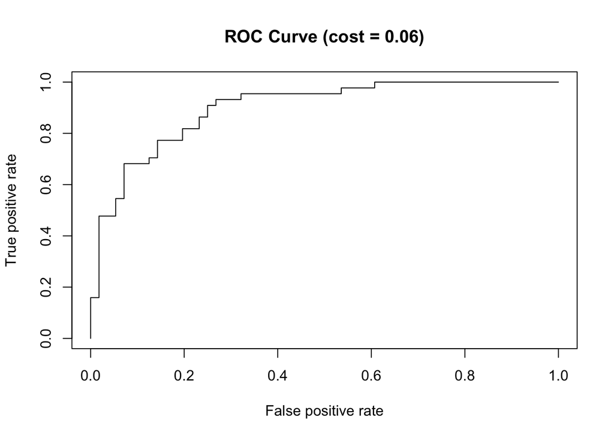

```r
# We see that error occurs at cost = 0.03, 0.05, 0.06, with the latter having the lowest dispersion, hence cost = 0.06 will be the value going forward.

# Fitting new cost tuned model to compare to model 1
set.seed(1)
SVM_model2 <- svm(Class ~ ., data = train_data, type = "C-classification",
                kernel = "linear", cost = 0.06, decision.values = TRUE)

scores_model2 <- attributes(predict(SVM_model2, test_data, decision.values = TRUE))$decision.values

pred_model2 <- ROCR::prediction(scores_model2, test_data$Class)
perf_model2 <- ROCR::performance(pred_model2, "tpr", "fpr")

par(mfrow = c(1, 1))
plot(perf_model2, main = "ROC Curve (cost = 0.06)")
```

```r
auc_model2 <- ROCR::performance(pred_model2, "auc")@y.values[[1]]
auc_model2
```

```
[1] 0.8981331
```

```r
# 0.898
# Model 2 better than model 1


# Classification error and confusion matrix
pred_class_linear <- predict(SVM_model2, test_data)
error_linear <- mean(pred_class_linear != test_data$Class)
error_linear
```

```
[1] 0.18
```

```r
table(ActualClass = test_data$Class, Prediction = pred_class_linear)
```

```
           Prediction
ActualClass -1  1
         -1 48  8
         1  10 34
```

Here we see a slight improvement of AUC when compared the the baseline model. It is also worth noting that the false negative count here is 10, which is an impovement on the baseline model meaning we miss less cancers with this model.

Radial Kernel Analysis: This allows testing of different boundary types. Again, the kernel will be assessed on both AUC and false negative rate, with the latter being more influential in the optimisation of the model.

```r
set.seed(1)
train_data$Class <- as.factor(train_data$Class)
test_data$Class  <- as.factor(test_data$Class)

radial.tune <- tune(svm, Class ~., data = train_data,
                    type = "C-classification", kernel = "radial",
                    ranges = list(cost  = c(0.1, 1, 10, 100),
                                  gamma = c(0.001, 0.01, 0.05, 0.1, 0.5)))
summary(radial.tune)
```

```
Parameter tuning of 'svm':

- sampling method: 10-fold cross validation

- best parameters:
 cost gamma
    1  0.05

- best performance: 0.28

- Detailed performance results:
    cost gamma error dispersion
1    0.1 0.001  0.44  0.1577621
2    1.0 0.001  0.44  0.1577621
3   10.0 0.001  0.32  0.1475730
4  100.0 0.001  0.33  0.1251666
5    0.1 0.010  0.44  0.1577621
6    1.0 0.010  0.30  0.1563472
7   10.0 0.010  0.33  0.1636392
8  100.0 0.010  0.32  0.1475730
9    0.1 0.050  0.44  0.1577621
10   1.0 0.050  0.28  0.1475730
11  10.0 0.050  0.29  0.1663330
12 100.0 0.050  0.29  0.1663330
13   0.1 0.100  0.44  0.1577621
14   1.0 0.100  0.35  0.1649916
15  10.0 0.100  0.33  0.1337494
16 100.0 0.100  0.33  0.1337494
17   0.1 0.500  0.44  0.1577621
18   1.0 0.500  0.44  0.1577621
19  10.0 0.500  0.44  0.1577621
20 100.0 0.500  0.44  0.1577621
```

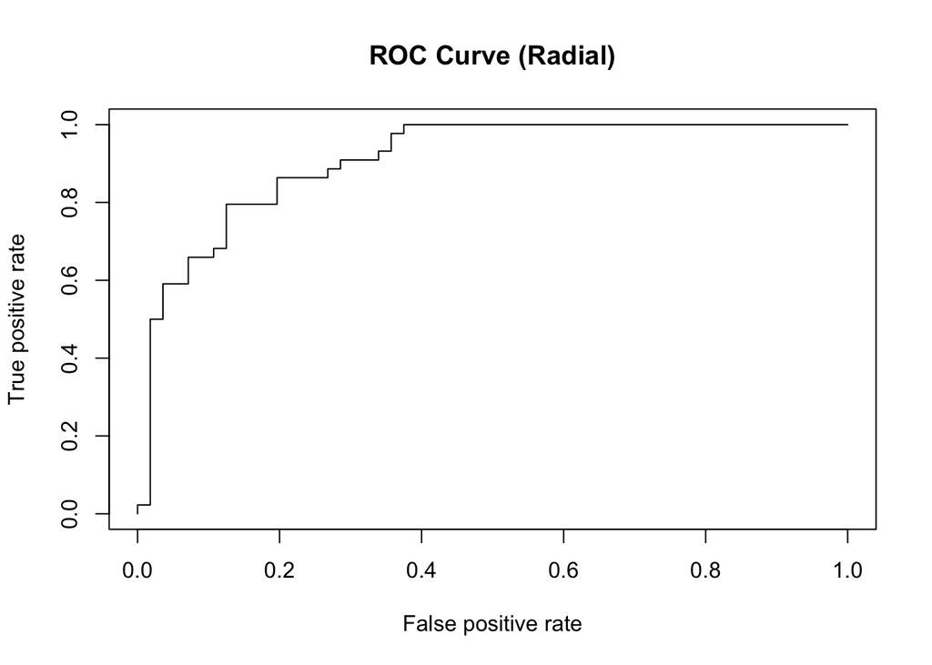

```r
# We see minimum error at cost = 1, gamma = 0.05
# We will test both of these cases against the linear model
set.seed(1)
svm_radial <- svm(Class ~ ., data = train_data, type = "C-classification",
                kernel = "radial", cost = 1, gamma = 0.05,
                decision.values = TRUE)

scores_radial <- attributes(predict(svm_radial, test_data, decision.values = TRUE))$decision.values

pred_radial <- ROCR::prediction(scores_radial, test_data$Class)
perf_radial <- ROCR::performance(pred_radial, "tpr", "fpr")
par(mfrow = c(1, 1))
plot(perf_radial, main = "ROC Curve (Radial)")
```

```r
auc_radial <- ROCR::performance(pred_radial, "auc")@y.values[[1]]
auc_radial
```

```
[1] 0.9082792
```

```r
# 0.908
# This is better than the linear model based on AUC

# Classification error and confusion matrix
pred_class_radial <- predict(svm_radial, test_data)
error_radial <- mean(pred_class_radial != test_data$Class)
error_radial
```

```
[1] 0.22
```

```r
table(ActualClass = test_data$Class, Prediction = pred_class_radial)
```

```
           Prediction
ActualClass -1  1
         -1 37 19
         1   3 41
```

```r
# We get very few false negatives: this is good for cancer
```

The raidal RBF kernel, has a greater AUC than the tuned linear model, along with producing only 3 false negative counts, this means that of the 100 tumours, we only miss three cancerous ones, while correctly identifying 41 cancers. There are 19 false positive rates, but given the context of the problem this is not as alarming as it may seem as the most dangerous inaccuracy is false negative.

Degree 2 Polynomial Kernel Test: This is similar to the above test but for polynomial of degree 2

```r
# Tune polynomial kernel (degree 2) over cost, gamma and coef0
set.seed(1)
poly.tune <- tune(svm, Class ~., data = train_data,
                  type = "C-classification", kernel = "polynomial", degree = 2, ranges = list(cost  = c(0.1, 1, 5),
                                                                                              gamma = c(0.01, 0.05, 0.1),
                                                                                              coef0 = c(0, 1, 2, 3)))
summary(poly.tune)
```

```
Parameter tuning of 'svm':

- sampling method: 10-fold cross validation

- best parameters:
 cost gamma coef0
    1  0.01     2

- best performance: 0.22

- Detailed performance results:
   cost gamma coef0 error dispersion
1   0.1  0.01     0  0.44 0.15776213
2   1.0  0.01     0  0.44 0.15776213
3   5.0  0.01     0  0.38 0.15491933
```

[output cut: 33 more lines]

```r
poly.tune$best.model
```

```
Call:
best.tune(METHOD = svm, train.x = Class ~ ., data = train_data, ranges = list(cost = c(0.1,
    1, 5), gamma = c(0.01, 0.05, 0.1), coef0 = c(0, 1, 2, 3)), type = "C-classification",
    kernel = "polynomial", degree = 2)


Parameters:
   SVM-Type:  C-classification
 SVM-Kernel:  polynomial
       cost:  1
     degree:  2
     coef.0:  2

Number of Support Vectors:  72
```

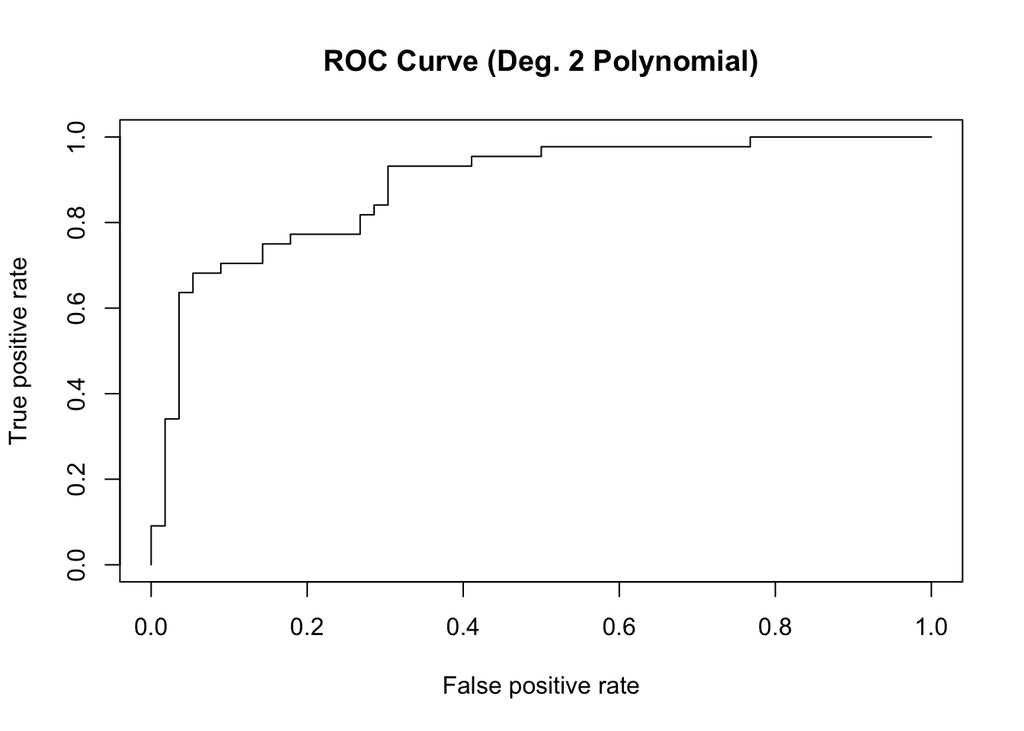

```r
# creat updated SVM:
svm_poly <- svm(Class ~ ., data = train_data, type = "C-classification", kernel = "polynomial",degree = 2, cost = 1,
                  gamma = 0.05, coef0 = 2, decision.values = TRUE)

# Evaluate on test set
scores_poly <- attributes(predict(svm_poly, test_data, decision.values = TRUE))$decision.values
pred_poly <- ROCR::prediction(scores_poly, test_data$Class)
perf_poly <- ROCR::performance(pred_poly, "tpr", "fpr")

par(mfrow = c(1, 1))
plot(perf_poly, main = "ROC Curve (Deg. 2 Polynomial)")
```

```r
auc_poly <- ROCR::performance(pred_poly, "auc")@y.values[[1]]
auc_poly
```

```
[1] 0.8855519
```

```r
# 0.886

# Classification error and confusion matrix
pred_class_poly <- predict(svm_poly, test_data)
error_poly <- mean(pred_class_poly != test_data$Class)
error_poly
```

```
[1] 0.2
```

```r
table(ActualClass = test_data$Class, Prediction = pred_class_poly)
```

```
           Prediction
ActualClass -1  1
         -1 47  9
         1  11 33
```

The AUC value is very slightly lower for the polynomial kernel SVM than for the radial kernel, suggesting radial is more accurate. Furthermore, there are 11 false negatives, over three times that of the radial kernel model.

Thus, the best model is the radial model.

## 1.5 Neural Network

We will now use a Neural Network (NN) to predict a classification. We will use a validation set to decide on the NN parameters, i.e. PCs used and number of hidden nodes. We use an 80/20 split.

```r
set.seed(123)

k <- 80

# 80/20 split
index <- sample(1:nrow(X_train), round(0.8 * nrow(X_train)))

# New test and valiation sets
X_subtrain <- X_train[index,]
X_valid    <- X_train[-index,]

# Classifications for new sets
y_subtrain <- y_train[index]
y_valid    <- y_train[-index]

# Remove zero-variance columns (causes an error when running PCA if we don't)
subtrain_sd <- apply(X_subtrain, 2, sd)
keep_cols <- subtrain_sd > 0

X_subtrain <- X_subtrain[, keep_cols]
X_valid    <- X_valid[, keep_cols]

# PCA on sub-training set
pca_fit <- prcomp(X_subtrain, scale. = TRUE)

# Define the Principal components for training and validation sets
train_pcs <- pca_fit$x[, 1:k]
valid_pcs <- predict(pca_fit, newdata = X_valid)[, 1:k]
```

We change the classification from -1 or 1, which it is in the original data, to 0 or 1 as this is what neuralnet assumes. We then construct the training and test sets for the NN.

```r
y_subtrain_bin <- ifelse(y_subtrain == "-1", 0, 1)
y_valid_bin  <- ifelse(y_valid  == "-1", 0, 1)

train_nn <- data.frame(Class = y_subtrain_bin, train_pcs)
valid_nn  <- data.frame(Class = y_valid_bin,  valid_pcs)
```

We ensure the training and validation sets contain observations of both classes.

```r
mean(y_subtrain_bin == 0)
```

```
[1] 0.5625
```

```r
mean(y_valid_bin == 0 )
```

```
[1] 0.55
```

Both have a roughly equal split so we continue.

We fit an initial NN using the logistic function and cross entropy loss.

```r
set.seed(123)
# Fit neural network
nn_fit <- neuralnet(
  Class ~ .,
  data = train_nn,
  hidden = c(5),          # 1 hidden layer with 5 neurons
  linear.output = FALSE,  # classification
  act.fct = "logistic",
  err.fct = "ce",         # cross-entropy
  likelihood = T
)
CE_loss <- round(nn_fit$result.matrix[1,1],3)
AIC <- round(nn_fit$result.matrix[4,1],3)
BIC <- round(nn_fit$result.matrix[5,1],3)

tibble('Metric' = c('AIC', 'BIC','CE Loss'),
                       'Value' = c(AIC, BIC, CE_loss)) %>% gt()
```

| Metric | Value |
| --- | --- |
| AIC | 822.130 |
| BIC | 1801.143 |
| CE Loss | 0.065 |

We will now look at the effect of varying the number of PCs used and the number of hidden nodes.

```r
set.seed(123)
results <- data.frame()

for (k in 10:80) {
 # training PCs
  train_pcs <- pca_fit$x[, 1:k]

  # validation PCs projected into the same PCA space
  valid_pcs <- predict(pca_fit, newdata = X_valid)[, 1:k]

  # data frames for neuralnet
  train_nn <- data.frame(Class = y_subtrain_bin, train_pcs)
  valid_nn <- data.frame(Class = y_valid_bin, valid_pcs)

  for (h in 5:15) {

    nn_fit <- neuralnet(
      Class ~ .,
      data = train_nn,
      hidden = c(h),
      linear.output = FALSE,
      act.fct = "logistic",
      err.fct = "ce",
      likelihood = TRUE
    )

    # numerical summaries
    CE_loss_train <- nn_fit$result.matrix[1, 1]
    AIC_train <- nn_fit$result.matrix[4, 1]
    BIC_train <- nn_fit$result.matrix[5, 1]

    # validation predictions
    valid_prob <- as.numeric(predict(nn_fit, valid_nn[,-1]))

    # convert probabilities into classification (i.e. assign to case if probability > 50%)
    valid_pred <- ifelse(valid_prob >= 0.5, 1, 0)

    valid_accuracy <- mean(valid_pred == y_valid_bin)

    results <- rbind(
      results,
      data.frame(
        PCs = k,
        hidden = h,
        AIC = AIC_train,
        BIC = BIC_train,
        TrainCrossEntropyLoss = CE_loss_train,
        ValidationAccuracy = valid_accuracy
      )
    )
  }
}

results %>%
  arrange(desc(ValidationAccuracy), hidden) %>%
  slice_head(n = 10) %>%
  gt()
```

| PCs | hidden | AIC | BIC | TrainCrossEntropyLoss | ValidationAccuracy |
| --- | --- | --- | --- | --- | --- |
| 59 | 10 | 1222.0300 | 2677.4482 | 0.01498615 | 0.90 |
| 17 | 11 | 420.0266 | 920.2522 | 0.01328087 | 0.90 |
| 23 | 14 | 702.0684 | 1538.1598 | 0.03420541 | 0.90 |
| 15 | 5 | 178.7912 | 383.6455 | 3.39559924 | 0.85 |
| 17 | 5 | 205.6772 | 434.3518 | 6.83861533 | 0.85 |
| 15 | 6 | 211.0724 | 456.4212 | 2.53622086 | 0.85 |
| 16 | 6 | 218.1080 | 477.7489 | 0.05400146 | 0.85 |
| 17 | 6 | 236.8014 | 510.7345 | 3.40071168 | 0.85 |
| 24 | 6 | 319.0552 | 693.0334 | 2.52761478 | 0.85 |
| 72 | 6 | 890.0594 | 1950.0612 | 0.02968235 | 0.85 |

Since multiple NNs get a validation accuracy score of 90% we use the simplest one, with 17 PCs and 11 hidden nodes. We define simplest here as the lowest AIC and BIC score. Note the validation accuracy changes by 0.05 as we only have 20 observations in the validation set, hence identifying one more observation correctly changes the score by 1 / 20 = 0.05. Now we fit our model.

```r
set.seed(123)

# Number of PCs
k <- 17
# Number of hidden nodes
h <- 11

# Perform PCA on whole training set
pca_fit <- prcomp(X_train, scale. = T)

# Define the Principal components for training and validation sets
train_pcs <- pca_fit$x[, 1:k]
test_pcs  <- predict(pca_fit, newdata = X_test)[, 1:k]

# Update classification to 0 or 1 (as required by neuralnet)
y_train_bin <- ifelse(y_train == "-1", 0, 1)
y_test_bin  <- ifelse(y_test  == "-1", 0, 1)

train_nn <- data.frame(Class = y_train_bin, train_pcs)
test_nn  <- data.frame(Class = y_test_bin, test_pcs)

# Create final neural network with optimised parameters
final_nn <- neuralnet(
  Class ~ .,
  data = train_nn,
  hidden = c(h),
  linear.output = FALSE,
  act.fct = "logistic",
  err.fct = "ce",
  likelihood = TRUE
)

# Make classifications on test set based on our NN
test_prob <- as.numeric(predict(final_nn, test_nn[,-1]))
test_pred <- ifelse(test_prob >= 0.5, 1, 0)

# Compare our predicted classifications to actual
test_accuracy <- mean(test_pred == y_test_bin)
test_accuracy
```

```
[1] 0.87
```

```r
cm <- table(Predicted = test_pred, Actual = y_test_bin)
cm
```

```
         Actual
Predicted  0  1
        0 49  6
        1  7 38
```

This gives a test accuracy of 87%. We will now look at the false positives/negatives rate.

```r
TN <- cm["0", "0"]
FN <- cm["0", "1"]
FP <- cm["1", "0"]
TP <- cm["1", "1"]

false_positive_rate <- FP / (FP + TN)
false_negative_rate <- FN / (FN + TP)

false_positive_rate
```

```
[1] 0.125
```

```r
false_negative_rate
```

```
[1] 0.1363636
```

This gives a false negative rate of roughly 0.14.

## 1.6 Classification Trees

We now use binary classification trees to predict the class of tissue samples. To begin, trees will be fit to the data for different numbers of PCS. A topdown approach will be taken to fit full trees and prune them according to the minumum error criterion, which produces more accurate results than the smallest tree criterion.

First we use 40 PCs, which capture 80% of variability in the data

```r
#Apply PCA to our training and test data
PCA40_train <- data.frame(Class = as.factor(y_train), predict(pca_fit, X_train)[,1:40])
PCA40_test <- data.frame(Class = as.factor(y_test), predict(pca_fit, X_test)[,1:40])

# Full tree:
tree_PCA40_full <- rpart(Class~., data=PCA40_train, method="class", minsplit=2,
                        minbucket=1, cp=-1)
tree_PCA40_full
```

```
n= 100

node), split, n, loss, yval, (yprob)
      * denotes terminal node

  1) root 100 44 -1 (0.56000000 0.44000000)
    2) PC13< -2.115473 30  2 -1 (0.93333333 0.06666667)
      4) PC11>=-15.38753 29  1 -1 (0.96551724 0.03448276)
        8) PC1>=-25.22655 27  0 -1 (1.00000000 0.00000000) *
        9) PC1< -25.22655 2  1 -1 (0.50000000 0.50000000)
         18) PC1< -25.54612 1  0 -1 (1.00000000 0.00000000) *
         19) PC1>=-25.54612 1  0 1 (0.00000000 1.00000000) *
      5) PC11< -15.38753 1  0 1 (0.00000000 1.00000000) *
    3) PC13>=-2.115473 70 28 1 (0.40000000 0.60000000)
      6) PC5< -3.27264 17  4 -1 (0.76470588 0.23529412)
       12) PC9< 5.393181 12  0 -1 (1.00000000 0.00000000) *
       13) PC9>=5.393181 5  1 1 (0.20000000 0.80000000)
         26) PC3>=24.94649 1  0 -1 (1.00000000 0.00000000) *
         27) PC3< 24.94649 4  0 1 (0.00000000 1.00000000) *
      7) PC5>=-3.27264 53 15 1 (0.28301887 0.71698113)
       14) PC1>=22.91808 12  3 -1 (0.75000000 0.25000000)
         28) PC9< 0.6941073 9  0 -1 (1.00000000 0.00000000) *
         29) PC9>=0.6941073 3  0 1 (0.00000000 1.00000000) *
       15) PC1< 22.91808 41  6 1 (0.14634146 0.85365854)
         30) PC38< -4.406226 4  0 -1 (1.00000000 0.00000000) *
         31) PC38>=-4.406226 37  2 1 (0.05405405 0.94594595)
           62) PC35>=8.704002 1  0 -1 (1.00000000 0.00000000) *
           63) PC35< 8.704002 36  1 1 (0.02777778 0.97222222)
            126) PC1< -25.47351 3  1 1 (0.33333333 0.66666667)
              252) PC1>=-25.59862 1  0 -1 (1.00000000 0.00000000) *
              253) PC1< -25.59862 2  0 1 (0.00000000 1.00000000) *
            127) PC1>=-25.47351 33  0 1 (0.00000000 1.00000000) *
```

```r
# Pruning:
printcp(tree_PCA40_full)
```

```
Classification tree:
rpart(formula = Class ~ ., data = PCA40_train, method = "class",
    minsplit = 2, minbucket = 1, cp = -1)

Variables actually used in tree construction:
[1] PC1  PC11 PC13 PC3  PC35 PC38 PC5  PC9

Root node error: 44/100 = 0.44

n= 100

         CP nsplit rel error  xerror     xstd
1  0.318182      0  1.000000 1.00000 0.112815
2  0.204545      1  0.681818 0.90909 0.111340
3  0.136364      2  0.477273 0.72727 0.106017
4  0.090909      3  0.340909 0.63636 0.102045
5  0.068182      4  0.250000 0.56818 0.098412
6  0.022727      6  0.113636 0.52273 0.095644
7  0.011364      9  0.045455 0.68182 0.104149
8 -1.000000     13  0.000000 0.68182 0.104149
```

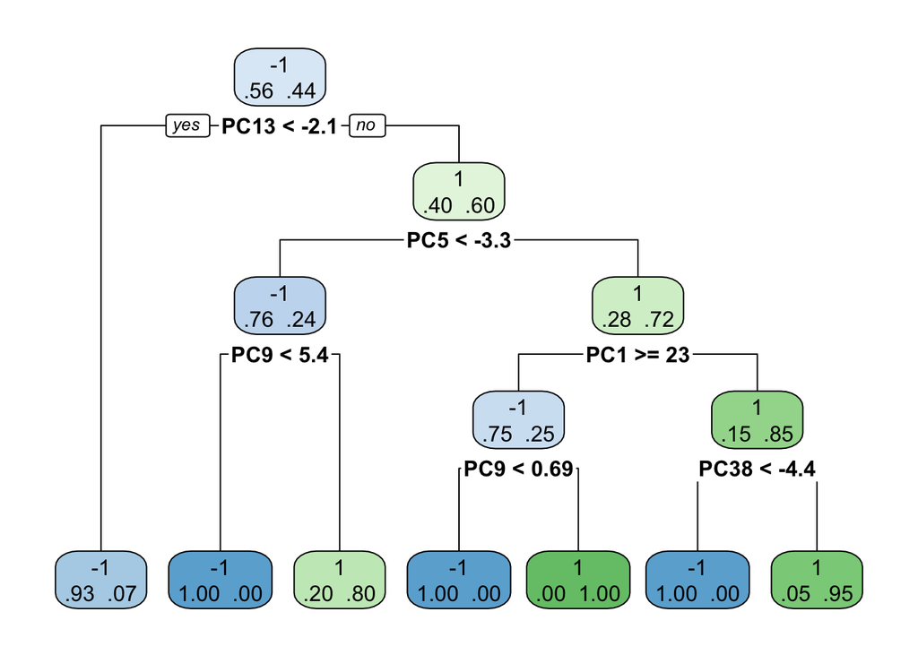

```r
# Minimum xerror: Tree 6, cp=0.022727
tree_PCA40 <- prune(tree_PCA40_full, cp=0.023)
rpart.plot(tree_PCA40, type=2, extra=4 )
```

```r
tree_PCA40
```

```
n= 100

node), split, n, loss, yval, (yprob)
      * denotes terminal node

 1) root 100 44 -1 (0.56000000 0.44000000)
   2) PC13< -2.115473 30  2 -1 (0.93333333 0.06666667) *
   3) PC13>=-2.115473 70 28 1 (0.40000000 0.60000000)
     6) PC5< -3.27264 17  4 -1 (0.76470588 0.23529412)
      12) PC9< 5.393181 12  0 -1 (1.00000000 0.00000000) *
      13) PC9>=5.393181 5  1 1 (0.20000000 0.80000000) *
     7) PC5>=-3.27264 53 15 1 (0.28301887 0.71698113)
      14) PC1>=22.91808 12  3 -1 (0.75000000 0.25000000)
        28) PC9< 0.6941073 9  0 -1 (1.00000000 0.00000000) *
        29) PC9>=0.6941073 3  0 1 (0.00000000 1.00000000) *
      15) PC1< 22.91808 41  6 1 (0.14634146 0.85365854)
        30) PC38< -4.406226 4  0 -1 (1.00000000 0.00000000) *
        31) PC38>=-4.406226 37  2 1 (0.05405405 0.94594595) *
```

Assessing variable importance in this tree shows that PC13 is the most important variable (13.75), with most PCs beyond 13 holding very little importance. PC38 is the only important PC above 13 (6.46).

```r
tree_PCA40$variable.importance
```

```
     PC13       PC5       PC9       PC6       PC1      PC38      PC10       PC3
13.753725  9.355685  9.017647  7.380879  6.765532  6.460119  6.422088  5.904533
      PC7      PC21       PC4       PC2      PC15      PC40      PC14      PC16
 5.256903  4.500000  4.266496  3.747852  3.723119  3.230059  3.000000  3.000000
     PC20      PC27      PC22      PC17      PC28
 2.818971  2.710588  1.691383  1.194667  1.194667
```

```r
# PC13 is significantly most important, 13 PCs only explain 62% of variability though
# PC38 is relatively important, but maybe not enough to justify that many more?
```

We now assess the accuracy of this tree by using it to predict the class of samples in the test data. The test accuracy of this tree is 69%, not a particularly good score.

```r
# Now to assess overall accuracy of this tree
tree_PCA40_pred <- predict(tree_PCA40, newdata=PCA40_test, type="class")
class_rate_tree40 <- mean(tree_PCA40_pred==PCA40_test$Class)
class_rate_tree40
```

```
[1] 0.69
```

Before fitting different tree based methods to improve this accuracy, it is worth investigating whether using a different number of PCs improves accuracy.

We repeat the process using 50 PCs, which capture 85% of the variability in the data.

```r
PCA50_train <- data.frame(Class = as.factor(y_train), predict(pca_fit, X_train)[,1:50])
PCA50_test <- data.frame(Class = as.factor(y_test), predict(pca_fit, X_test)[,1:50])

# Full tree:
tree_PCA50_full <- rpart(Class~., data=PCA50_train, method="class", minsplit=2,
                         minbucket=1, cp=-1)
tree_PCA50_full
```

```
n= 100

node), split, n, loss, yval, (yprob)
      * denotes terminal node

  1) root 100 44 -1 (0.56000000 0.44000000)
    2) PC13< -2.115473 30  2 -1 (0.93333333 0.06666667)
      4) PC11>=-15.38753 29  1 -1 (0.96551724 0.03448276)
        8) PC1>=-25.22655 27  0 -1 (1.00000000 0.00000000) *
        9) PC1< -25.22655 2  1 -1 (0.50000000 0.50000000)
         18) PC1< -25.54612 1  0 -1 (1.00000000 0.00000000) *
         19) PC1>=-25.54612 1  0 1 (0.00000000 1.00000000) *
      5) PC11< -15.38753 1  0 1 (0.00000000 1.00000000) *
    3) PC13>=-2.115473 70 28 1 (0.40000000 0.60000000)
      6) PC5< -3.27264 17  4 -1 (0.76470588 0.23529412)
       12) PC9< 5.393181 12  0 -1 (1.00000000 0.00000000) *
       13) PC9>=5.393181 5  1 1 (0.20000000 0.80000000)
         26) PC3>=24.94649 1  0 -1 (1.00000000 0.00000000) *
         27) PC3< 24.94649 4  0 1 (0.00000000 1.00000000) *
      7) PC5>=-3.27264 53 15 1 (0.28301887 0.71698113)
       14) PC1>=22.91808 12  3 -1 (0.75000000 0.25000000)
         28) PC9< 0.6941073 9  0 -1 (1.00000000 0.00000000) *
         29) PC9>=0.6941073 3  0 1 (0.00000000 1.00000000) *
       15) PC1< 22.91808 41  6 1 (0.14634146 0.85365854)
         30) PC38< -4.406226 4  0 -1 (1.00000000 0.00000000) *
         31) PC38>=-4.406226 37  2 1 (0.05405405 0.94594595)
           62) PC35>=8.704002 1  0 -1 (1.00000000 0.00000000) *
           63) PC35< 8.704002 36  1 1 (0.02777778 0.97222222)
            126) PC44>=7.32343 1  0 -1 (1.00000000 0.00000000) *
            127) PC44< 7.32343 35  0 1 (0.00000000 1.00000000) *
```

```r
# Pruning:
printcp(tree_PCA50_full)
```

```
Classification tree:
rpart(formula = Class ~ ., data = PCA50_train, method = "class",
    minsplit = 2, minbucket = 1, cp = -1)

Variables actually used in tree construction:
[1] PC1  PC11 PC13 PC3  PC35 PC38 PC44 PC5  PC9

Root node error: 44/100 = 0.44

n= 100

         CP nsplit rel error  xerror    xstd
1  0.318182      0  1.000000 1.00000 0.11282
2  0.204545      1  0.681818 1.00000 0.11282
3  0.136364      2  0.477273 0.81818 0.10909
4  0.090909      3  0.340909 0.81818 0.10909
5  0.068182      4  0.250000 0.77273 0.10766
6  0.022727      6  0.113636 0.63636 0.10205
7  0.011364     10  0.022727 0.63636 0.10205
8 -1.000000     12  0.000000 0.63636 0.10205
```

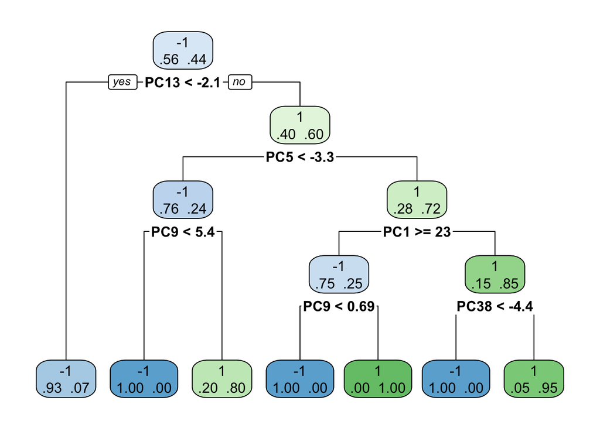

```r
# Minimum xerror: Tree 6, cp=0.022727
# There appears to be an optimal complexity parameter
tree_PCA50 <- prune(tree_PCA50_full, cp=0.023)
rpart.plot(tree_PCA50, type=2, extra=4 )
```

```r
tree_PCA50
```

```
n= 100

node), split, n, loss, yval, (yprob)
      * denotes terminal node

 1) root 100 44 -1 (0.56000000 0.44000000)
   2) PC13< -2.115473 30  2 -1 (0.93333333 0.06666667) *
   3) PC13>=-2.115473 70 28 1 (0.40000000 0.60000000)
     6) PC5< -3.27264 17  4 -1 (0.76470588 0.23529412)
      12) PC9< 5.393181 12  0 -1 (1.00000000 0.00000000) *
      13) PC9>=5.393181 5  1 1 (0.20000000 0.80000000) *
     7) PC5>=-3.27264 53 15 1 (0.28301887 0.71698113)
      14) PC1>=22.91808 12  3 -1 (0.75000000 0.25000000)
        28) PC9< 0.6941073 9  0 -1 (1.00000000 0.00000000) *
        29) PC9>=0.6941073 3  0 1 (0.00000000 1.00000000) *
      15) PC1< 22.91808 41  6 1 (0.14634146 0.85365854)
        30) PC38< -4.406226 4  0 -1 (1.00000000 0.00000000) *
        31) PC38>=-4.406226 37  2 1 (0.05405405 0.94594595) *
```

```r
tree_PCA50$variable.importance
```

```
     PC13       PC5       PC9       PC6       PC1      PC38      PC10       PC7
13.753725  9.355685  9.017647  7.380879  6.765532  6.460119  6.422088  5.256903
      PC3      PC21       PC4       PC2      PC15      PC40      PC47      PC14
 5.108089  4.500000  4.266496  3.747852  3.723119  3.230059  3.230059  3.000000
     PC16      PC20      PC27      PC22      PC44      PC17      PC28
 3.000000  2.818971  2.710588  1.691383  1.592889  1.194667  1.194667
```

```r
# Similar to previous tree
# 13 at the top
```

And the test accuracy is 69% again, so this level of PCs leads to no improvement

```r
# Overall accuracy
tree_PCA50_pred <- predict(tree_PCA50, newdata=PCA50_test, type="class")
class_rate_tree50 <- mean(tree_PCA50_pred==PCA50_test$Class)
class_rate_tree50
```

```
[1] 0.69
```

The poor performance of these trees, and the large number of unimportant variables they both use, suggests that a lower number of PCs may be worth investigating.